# Relationship between ngrams and correlations

Saumya Mehta

5/15/2018

We can analyse which word immediatrly follow other words or tend to occur in same document. Tokens = “ngrams” argument in which tokenizes by pairs of adjacent words rather than individual words.  
ggraph extends ggplot2 to construct network plots and widyr which calculates the pairwise correlation nd distances withtin tidy data frame.

## Tokenizing by n-gram

By seeing how often a word X is followed by word Y, we can form a relationship between them.  
Set parameter n in unnest_tokens() for how many words you want to capture in n-grams.

```r
library(dplyr)
library(tidytext)
library(janeaustenr)

austen_bigrams <- austen_books() %>%
  unnest_tokens(bigram, text, token = "ngrams",n = 2)

austen_bigrams
```

```
## # A tibble: 725,049 x 2
##    book                bigram
##    <fct>               <chr>
##  1 Sense & Sensibility sense and
##  2 Sense & Sensibility and sensibility
##  3 Sense & Sensibility sensibility by
##  4 Sense & Sensibility by jane
##  5 Sense & Sensibility jane austen
##  6 Sense & Sensibility austen 1811
##  7 Sense & Sensibility 1811 chapter
##  8 Sense & Sensibility chapter 1
##  9 Sense & Sensibility 1 the
## 10 Sense & Sensibility the family
## # ... with 725,039 more rows
```

Now we count and filter the n grams

```r
austen_bigrams %>%
  count(bigram, sort=T)
```

```
## # A tibble: 211,236 x 2
##    bigram       n
##    <chr>    <int>
##  1 of the    3017
##  2 to be     2787
##  3 in the    2368
##  4 it was    1781
##  5 i am      1545
##  6 she had   1472
##  7 of her    1445
##  8 to the    1387
##  9 she was   1377
## 10 had been  1299
## # ... with 211,226 more rows
```

There are some pairs of stop words which we need to remove from the document. tidyr’s separate() splits column into multiple columns using a delimiter. So to remove stop words, split bigrams into 2 columns and apply rules for stop word removal on each column.

```r
library(tidyr)
bigrams_separated <- austen_bigrams %>%
  separate(bigram, c("word1","word2"), sep = " ")

bigrams_filtered <- bigrams_separated %>%
  filter(!word1 %in% stop_words$word) %>%
  filter(!word2 %in% stop_words$word)

# new bigram counts :
bigram_counts <- bigrams_filtered %>%
  count(word1, word2, sort = T)

bigram_counts
```

```
## # A tibble: 33,421 x 3
##    word1   word2         n
##    <chr>   <chr>     <int>
##  1 sir     thomas      287
##  2 miss    crawford    215
##  3 captain wentworth   170
##  4 miss    woodhouse   162
##  5 frank   churchill   132
##  6 lady    russell     118
##  7 lady    bertram     114
##  8 sir     walter      113
##  9 miss    fairfax     109
## 10 colonel brandon     108
## # ... with 33,411 more rows
```

We might want to combine the columns for some analysis so we can use unite function to combine different columns.

```r
bigrams_united <- bigrams_filtered %>%
  unite(bigram, word1,word2, sep = " ")

bigrams_united
```

```
## # A tibble: 44,784 x 2
##    book                bigram
##    <fct>               <chr>
##  1 Sense & Sensibility jane austen
##  2 Sense & Sensibility austen 1811
##  3 Sense & Sensibility 1811 chapter
##  4 Sense & Sensibility chapter 1
##  5 Sense & Sensibility norland park
##  6 Sense & Sensibility surrounding acquaintance
##  7 Sense & Sensibility late owner
##  8 Sense & Sensibility advanced age
##  9 Sense & Sensibility constant companion
## 10 Sense & Sensibility happened ten
## # ... with 44,774 more rows
```

## Analysing bigrams

One bigram per row format is useful for exploratory analysis of text.

```r
bigrams_filtered %>%
  filter(word2 == "street") %>%
  count(book, word1, sort = T)
```

```
## # A tibble: 34 x 3
##    book                word1           n
##    <fct>               <chr>       <int>
##  1 Sense & Sensibility berkeley       16
##  2 Sense & Sensibility harley         16
##  3 Northanger Abbey    pulteney       14
##  4 Northanger Abbey    milsom         11
##  5 Mansfield Park      wimpole        10
##  6 Pride & Prejudice   gracechurch     9
##  7 Sense & Sensibility conduit         6
##  8 Sense & Sensibility bond            5
##  9 Persuasion          milsom          5
## 10 Persuasion          rivers          4
## # ... with 24 more rows
```

We can treat bigrams as term and as a result we can find the tf-idf for them and visualize it.

```r
bigram_tf_idf <- bigrams_united %>%
  count(book, bigram) %>%
  bind_tf_idf(bigram, book, n) %>%
  arrange(desc(tf_idf))

bigram_tf_idf
```

```
## # A tibble: 36,217 x 6
##    book                bigram                n     tf   idf tf_idf
##    <fct>               <chr>             <int>  <dbl> <dbl>  <dbl>
##  1 Persuasion          captain wentworth   170 0.0299  1.79 0.0535
##  2 Mansfield Park      sir thomas          287 0.0287  1.79 0.0515
##  3 Mansfield Park      miss crawford       215 0.0215  1.79 0.0386
##  4 Persuasion          lady russell        118 0.0207  1.79 0.0371
##  5 Persuasion          sir walter          113 0.0198  1.79 0.0356
##  6 Emma                miss woodhouse      162 0.0170  1.79 0.0305
##  7 Northanger Abbey    miss tilney          82 0.0159  1.79 0.0286
##  8 Sense & Sensibility colonel brandon     108 0.0150  1.79 0.0269
##  9 Emma                frank churchill     132 0.0139  1.79 0.0248
## 10 Pride & Prejudice   lady catherine      100 0.0138  1.79 0.0247
## # ... with 36,207 more rows
```

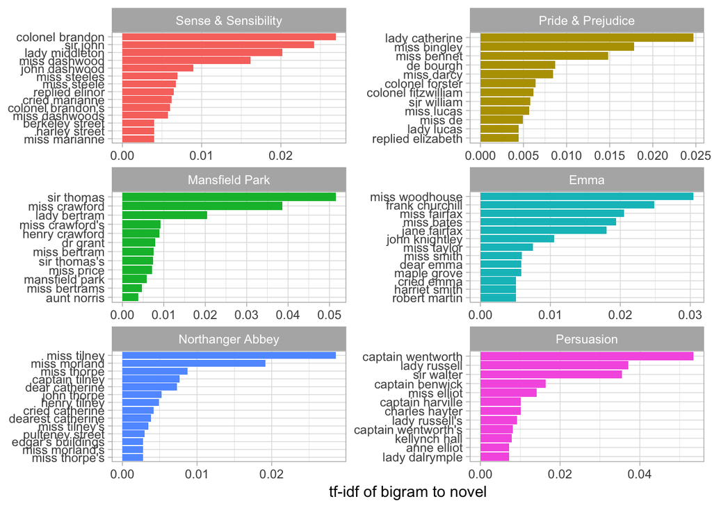

Figure 4.1: The 12 bigrams with the highest tf-idf from each Jane Austen novel

Pairs of words might capture the sentence structure which isn’t present when working with unigrams and provide a context which makes the tokens more understandable. Bigrams can be useful when we have a large text dataset.

## Using bigrams to provide context in sentiment analysis

During sentiment analysis on unigrams, we didn’t consider context of sentence and only positive or negative sentiment from each word. eg “I am not happy and I don’t like it”. Here sentiment may turn out to be positive due to happy and like. But when we do bigrams, we can count how many words preceed with not and find a negative sentiment.

```r
bigrams_separated %>%
  filter(word1 == "not") %>%
  count(word1,word2, sort = T)
```

```
## # A tibble: 1,246 x 3
##    word1 word2     n
##    <chr> <chr> <int>
##  1 not   be      610
##  2 not   to      355
##  3 not   have    327
##  4 not   know    252
##  5 not   a       189
##  6 not   think   176
##  7 not   been    160
##  8 not   the     147
##  9 not   at      129
## 10 not   in      118
## # ... with 1,236 more rows
```

Using AFINN lexicon for sentiment analysis.

```r
AFINN <- get_sentiments("afinn")
not_words <- bigrams_separated %>%
  filter(word1 == "not") %>%
  inner_join(AFINN, by = c(word2 = "word")) %>%
  count(word2, score, sort = T) %>%
  ungroup()

not_words
```

```
## # A tibble: 245 x 3
##    word2   score     n
##    <chr>   <int> <int>
##  1 like        2    99
##  2 help        2    82
##  3 want        1    45
##  4 wish        1    39
##  5 allow       1    36
##  6 care        2    23
##  7 sorry      -1    21
##  8 leave      -1    18
##  9 pretend    -1    18
## 10 worth       2    17
## # ... with 235 more rows
```

We can calculate which words contributed the most towards the wrong direction. We can simply multiply their score by the number of times they appear.

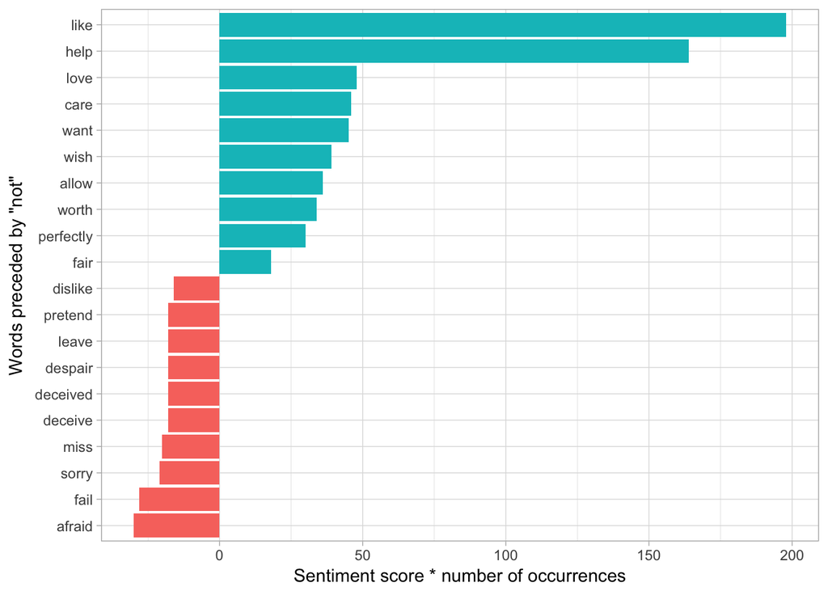

Figure 4.2: The 20 words preceded by ‘not’ that had the greatest contribution to sentiment scores, in either a positive or negative direction

## Visualizing a network of bigrams using ggraph

- A graph can be constructed from a tidy object since it has 3 variables :  
  1.) from  
  2.) to  
  3.) weight  
  Igraph package has many powerful tools for manipulating and analysing networks.  
  Create an igraph object using graph_from_data_frame() function.

[output not shown]

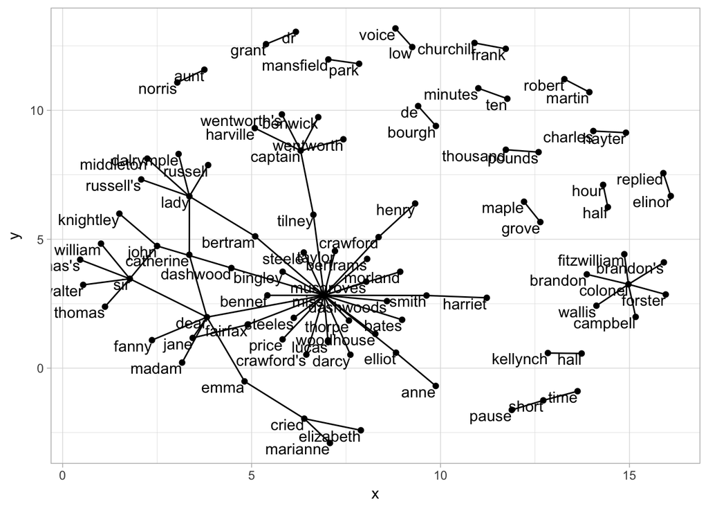

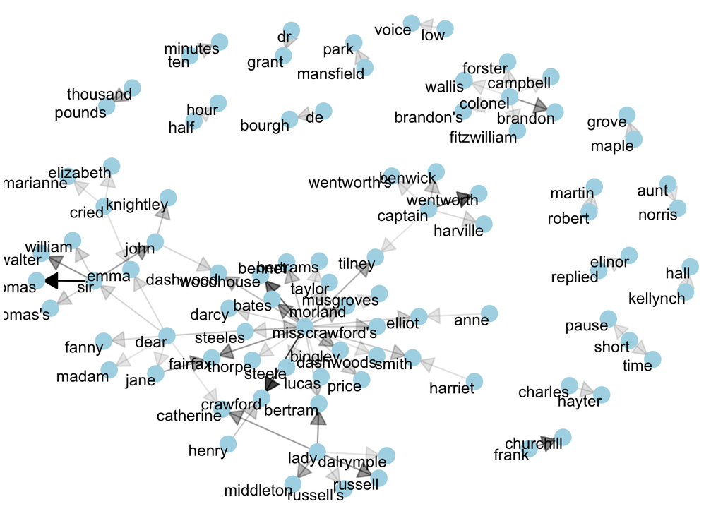

```r
library(igraph)
bigram_graph <- bigram_counts %>%
  filter(n>20) %>%
  graph_from_data_frame()

bigram_graph
```

In markov chain, the current word choice depends only on the previous words.

## counting and correlating the pairs of words using widyr package.

Aside of adjacent words, we may also be interested in knowing words that tend to occur in a particular document or chapter perhaps.  
Most of the operations to find pairwise counts or correlations need to turn the data into a matrix first.

## counting and correlating among the sections.

```r
austen_section_words <- austen_books() %>%
  filter(book == "Pride & Prejudice") %>%
  mutate(section = row_number() %/%10) %>%
  filter(section > 0) %>%
  unnest_tokens(word,text) %>%
  filter(!word %in% stop_words$word)

austen_section_words
```

```
## # A tibble: 37,240 x 3
##    book              section word
##    <fct>               <dbl> <chr>
##  1 Pride & Prejudice      1. truth
##  2 Pride & Prejudice      1. universally
##  3 Pride & Prejudice      1. acknowledged
##  4 Pride & Prejudice      1. single
##  5 Pride & Prejudice      1. possession
##  6 Pride & Prejudice      1. fortune
##  7 Pride & Prejudice      1. wife
##  8 Pride & Prejudice      1. feelings
##  9 Pride & Prejudice      1. views
## 10 Pride & Prejudice      1. entering
## # ... with 37,230 more rows
```

pairwise_count() results in a row of each pair of words in word variable.

```r
library(widyr)
```

```r
# count words co occuring in a section
word_pairs <- austen_section_words %>%
  pairwise_count(word, section, sort = T)

word_pairs
```

```
## # A tibble: 796,008 x 3
##    item1     item2         n
##    <chr>     <chr>     <dbl>
##  1 darcy     elizabeth  144.
##  2 elizabeth darcy      144.
##  3 miss      elizabeth  110.
##  4 elizabeth miss       110.
##  5 elizabeth jane       106.
##  6 jane      elizabeth  106.
##  7 miss      darcy       92.
##  8 darcy     miss        92.
##  9 elizabeth bingley     91.
## 10 bingley   elizabeth   91.
## # ... with 795,998 more rows
```

## Pairwise correlation

Phi coefficient is similar to pearson correlation when applied to binary data.  
The pairwise_cor() function in widyr lets us find the phi coefficient between words based on how often they appear in the same section.

```r
words_corr <- austen_section_words %>%
  group_by(word) %>%
  filter(n() >= 20) %>%
  pairwise_cor(word, section, sort = T)

words_corr
```

```
## # A tibble: 154,842 x 3
##    item1     item2     correlation
##    <chr>     <chr>           <dbl>
##  1 bourgh    de              0.962
##  2 de        bourgh          0.962
##  3 pounds    thousand        0.769
##  4 thousand  pounds          0.769
##  5 catherine lady            0.750
##  6 lady      catherine       0.750
##  7 william   sir             0.706
##  8 sir       william         0.706
##  9 forster   colonel         0.603
## 10 colonel   forster         0.603
## # ... with 154,832 more rows
```

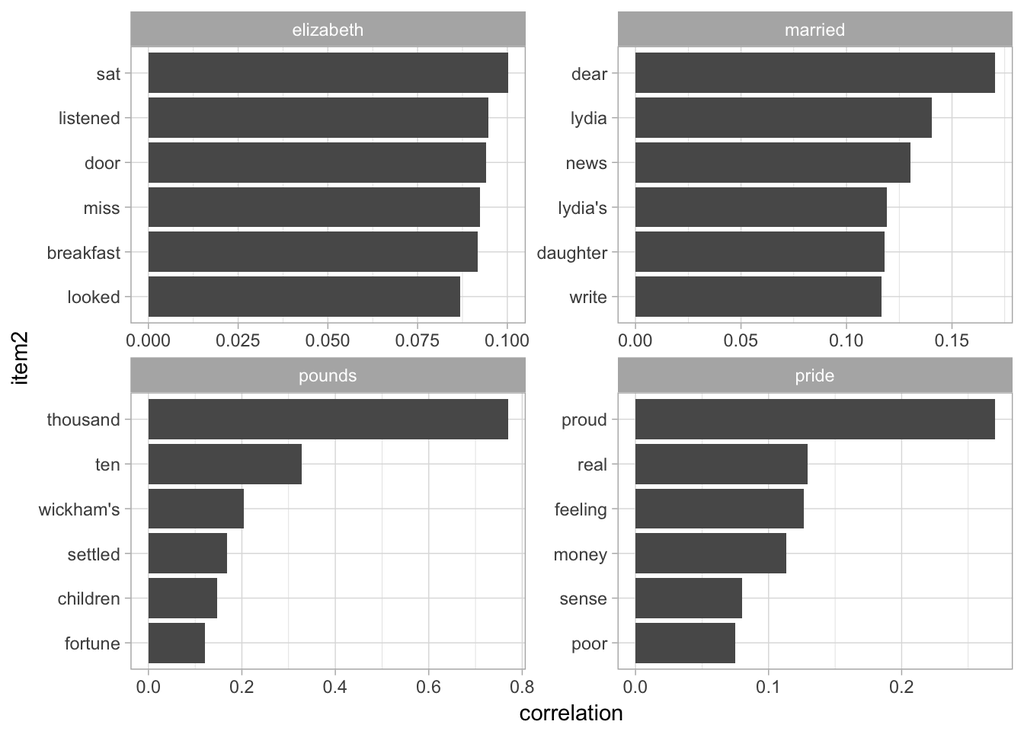

Figure 4.8: Words from Pride and Prejudice that were most correlated with ‘elizabeth’, ‘pounds’, ‘married’, and ‘pride’

Just like Bigrams, we can visualize the correlations and cluster of words found by widyr package.

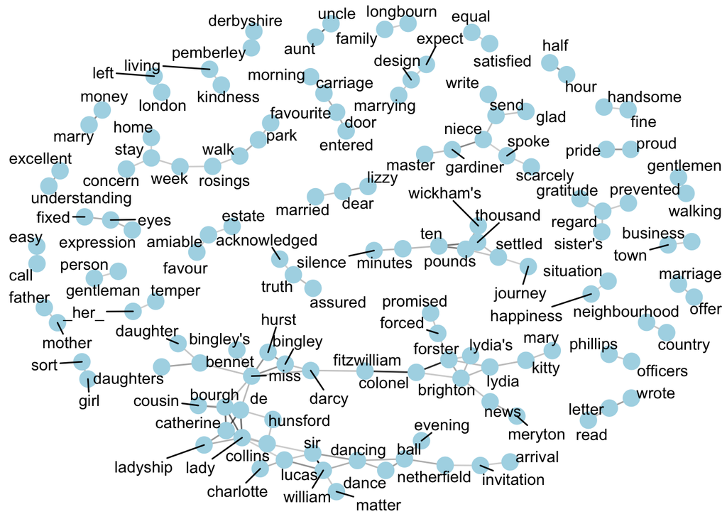

Figure 4.9: Pairs of words in Pride and Prejudice that show at least a .15 correlation of appearing within the same 10-line section